# Enron Fraud Detection using Email and Financial Data

### 1) Summarize for us the goal of this project and how machine learning is useful in trying to accomplish it. As part of your answer, give some background on the dataset and how it can be used to answer the project question. Were there any outliers in the data when you got it, and how did you handle those?

The goal of this project is to use email (text) and financial data to construct a predictive model that could identify an individual as a person of interest (poi). The [Enron corpus](https://www.cs.cmu.edu/~./enron/) was made public by the US Federal Energy Regulatory Comission during its investgiation of Enron, which comprised email and financial data of 146 individuals mostly in senior management positions. The data has been widely used for various machine learning problems. However, there is value in the mentioned analysis for potential use to identify similar cases in other companies or for spam filtering application. I decided to use both financial data and the email data and that reduced cases with both data available to 86 case (originaly 111). There were 18 pois at the beginning but email data was not available for 4 of them. Initially, 2 outliers were detected in the data. However, none of the outliers was detected in the final 86 cases since I only included cases with tmail data available. It should be mentioned that the current algorithm is only applicable if the email data is available and that is a very limiting factor.

### 2) What features did you end up using in your POI identifier, and what selection process did you use to pick them? Did you have to do any scaling? Why or why not? As part of the assignment, you should attempt to engineer your own feature that does not come ready-made in the dataset -- explain what feature you tried to make, and the rationale behind it.

I used ['bonus', 'deferral_payments', 'deferred_income', 'director_fees', 'exercised_stock_options', 'expenses', 'from_messages', 'from_poi_to_this_person', 'from_this_person_to_poi', 'loan_advances', 'long_term_incentive', 'other', 'restricted_stock', 'restricted_stock_deferred', 'salary', 'shared_receipt_with_poi', 'to_messages', 'total_payments', 'total_stock_value'].

I also engineered ['all_messages', 'all_poi_messages', 'poi_to_all_ratio', 'total_payments_log', 'salary_log', 'bonus_log', 'total_stock_value_log', 'exercised_stock_options_log', 'loan_advances_log', 'director_fees_log', 'restricted_stock_log', 'deferral_payments_log', 'total_payments_sqrt', 'salary_sqrt', 'bonus_sqrt', 'total_stock_value_sqrt', 'exercised_stock_options_sqrt', 'loan_advances_sqrt', 'director_fees_sqrt', 'restricted_stock_sqrt', 'deferral_payments_sqrt', 'total_payments_squared', 'salary_squared', 'bonus_squared', 'total_stock_value_squared', 'exercised_stock_options_squared', 'loan_advances_squared', 'director_fees_squared', 'restricted_stock_squared', 'deferral_payments_sqrd'] In addition, after performing feature selection, and PCA on the results of the tfidf analysis, 68 features were added to the databse.

The log and squared features were used to add non-linear representation of the features to the dataset.

Finally, MinMax Scaling was performed on the dataset to help some possible algorithms such as Naive Bayes, SGD, and KNN might need scaling.

It should be mentioned that, the data pipeline consisted of a SelectPercentile function with an ANOVA (fclassf) classifer followed by pca. Based on a grid-search, 10% of the data was preserved and 68 principal components were extracted from them. A plot of change of f1_score with percentile of data is shown below.

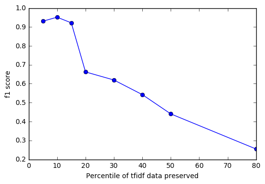

```python
import matplotlib.pyplot as plt
import pickle
%matplotlib inline
percentiles, f1_scores=pickle.load(file('f1plot.pickle'))
ax = plt.plot(percentiles, f1_scores, '-bo')
plt.xlabel('Percentile of tfidf data preserved')
plt.ylabel('f1 score')
plt.show()
```

```python
e_v = pickle.load(file('pca.pickle'))
print e_v.head(15)
```

```
    Explained_variance
0             0.015181
1             0.014482
2             0.014199
3             0.013586
4             0.013410
5             0.012872
6             0.012675
7             0.012514
8             0.009947
9             0.008514
10            0.004101
11            0.001957
12            0.001756
13            0.001623
14            0.001512
```

### 3) What algorithm did you end up using? What other one(s) did you try? How did model performance differ between algorithms?

I ended up using random forest. I tried random forest, decision trees, svm, adaboost, logistic regression, naive bayes, and SGD(linear models). I noticed that tree base algorithms (decision tree, random forest, and adaboost) given some measures to prevent overfitting, perform better that the others.

Precision and Recall of the top performing algorithm trained and cross-validated on the training data can be found below.

| Algorithm | Precision | Recall |
| --- | --- | --- |
| Random Forest | 0.97 | 0.78 |
| Ada Boost | 0.82 | 0.89 |
| Decision Tree | 0.80 | 0.80 |

However, the final values after training and testing the random forest classifier on the whole dataset are as follows:

| Algorithm | Precision | Recall |
| --- | --- | --- |
| Random Forest | 0.90 | 0.52 |

### 4) What does it mean to tune the parameters of an algorithm, and what can happen if you don’t do this well? How did you tune the parameters of your particular algorithm?

Performance of any algorithm depends on multiple parameters that can be tuned. If tuning is not performed a sub-standard algorithm might be used. I used GridSearchCV to tune algorithms first. After tuning, I used the best estimator for final classifiers used to asses performance of each algorithm.

### 5) What is validation, and what’s a classic mistake you can make if you do it wrong? How did you validate your analysis?

Validation is a set of techniques to ensure the model generalizes well with unseen data. Classic mistakes are overfitting or validating with the training data. Over-fitting happens when the model performes well on training data but demonstrate substantially lower performance on the test set. One of the hardest aspects of this analysis was the limited amount of training and test data that were available (only 14 pois, overall). In order to perform validation, I used the test_classifier function, which uses cross_validation to fit and measure performance. The test_classifier function stratified shuffle to split the data into training and test datasets. The small data set is why I used StratifiedShuffleSplit instead of a simpler cross-validation method such as TrainTestSplit. StratifiedShuffleSplit will make randomly chosen training and test sets multiple times and average the results over all the tests. The data is unbalanced with many more non-POIs than POIs. StratifidShuffleSplit also makes sure that the ratio of non-POI:POI is the same in the training and test sets as it was in the larger data set. The unbalanced data is also why we use precision and recall instead of accuracy as our evaluation metric.

### 6) Give at least 2 evaluation metrics and your average performance for each of them. Explain an interpretation of your metrics that says something human-understandable about your algorithm’s performance.

The main evaluation metrics in this staudy are precision, recall, and F1_score.

I ended up with precision of 0.90. 0.90 precision means that, if the model predict an individual as being a person of interest, there is a 90% chance that the the model is correct.

In addition, I received a recall score of 0.52, which means that, the model can identify 52 % of the persons of interest in the dataset.

F1-score is a mixture of precisin and recal score that range between 0 and 1, with 1 being the best. My model received F1_score of 0.66.